# u01

## Shared Qs (u01)

#### Question

1. *S-IC.A.1: Understand statistics as a process for making inferences to be made about population parameters based on a random sample from that population.*

### Background and future connections

   Below are some important definitions:
   - Sample: A smaller group taken from the population.
   - Sample Statistic: A number that describes the sample.
   - Population: The entire group of interest.
   - Population Parameter: A number that describes the entire population.

   In Statistics, we learn a process for making inferences about population parameters based on a random sample from that population. For a simple parameter, like an average or proportion, the sample statistic will be a best-guess estimate for the corresponding population parameter (for estimating the population’s [standard deviation](https://en.wikipedia.org/wiki/Standard_deviation), we will use [Bessel’s correction](https://en.wikipedia.org/wiki/Bessel%27s_correction) to find a best-guess estimate from the sample). Later, we will also learn how to express the amount of uncertainty in the estimation. (See [confidence interval](https://en.wikipedia.org/wiki/Confidence_interval) and [margin of error](https://en.wikipedia.org/wiki/Margin_of_error) to preview how we express uncertainty about the population parameter.)

   For now, let’s practice identifying the sample, statistic, population, and parameter.

### Actual Question

   A park ranger wants to know the average age of all the oak trees in a forest. They randomly select $20$ oak trees and find an average age of $100$ years.

   The four concepts are described in random order below.
   1. All the oak trees in the forest
   2. The $20$ oak trees that the ranger selected
   3. The average age of $100$ years found in the sample of oak trees
   4. The average age of all the oak trees in the forest

   Match the concept to the description.
   1. Sample =
   2. Statistic =
   3. Population =
   4. Parameter =

#### Solution

#### Question

2. *S-IC.A.1: Understand statistics as a process for making inferences to be made about population parameters based on a random sample from that population.*

### Background and future connections

   Below are some important definitions:
   - Sample: A smaller group taken from the population.
   - Sample Statistic: A number that describes the sample.
   - Population: The entire group of interest.
   - Population Parameter: A number that describes the entire population.

   In Statistics, we learn a process for making inferences about population parameters based on a random sample from that population. For a simple parameter, like an average or proportion, the sample statistic will be a best-guess estimate for the corresponding population parameter (for estimating the population’s [standard deviation](https://en.wikipedia.org/wiki/Standard_deviation), we will use [Bessel’s correction](https://en.wikipedia.org/wiki/Bessel%27s_correction) to find a best-guess estimate from the sample). Later, we will also learn how to express the amount of uncertainty in the estimation. (See [confidence interval](https://en.wikipedia.org/wiki/Confidence_interval) and [margin of error](https://en.wikipedia.org/wiki/Margin_of_error) to preview how we express uncertainty about the population parameter.)

   For now, let’s practice identifying the sample, statistic, population, and parameter.

### Actual Question

   A librarian is interested in the average number of pages in all the books in the library’s children’s section. They randomly select $15$ books from the children’s section and find an average of $80$ pages per book.

   The four concepts are described in random order below.
   1. All the books in the library’s children’s section
   2. The average of $80$ pages per book found in the sample
   3. The average number of pages in all the books in the library’s children’s section
   4. The $15$ books that the librarian selected

   Match the concept to the description.
   1. Sample =
   2. Statistic =
   3. Population =
   4. Parameter =

#### Solution

#### Question

3. *S-IC.A.1: Understand statistics as a process for making inferences to be made about population parameters based on a random sample from that population.*

### Background and future connections

   Below are some important definitions:
   - Sample: A smaller group taken from the population.
   - Sample Statistic: A number that describes the sample.
   - Population: The entire group of interest.
   - Population Parameter: A number that describes the entire population.

   In Statistics, we learn a process for making inferences about population parameters based on a random sample from that population. For a simple parameter, like an average or proportion, the sample statistic will be a best-guess estimate for the corresponding population parameter (for estimating the population’s [standard deviation](https://en.wikipedia.org/wiki/Standard_deviation), we will use [Bessel’s correction](https://en.wikipedia.org/wiki/Bessel%27s_correction) to find a best-guess estimate from the sample). Later, we will also learn how to express the amount of uncertainty in the estimation. (See [confidence interval](https://en.wikipedia.org/wiki/Confidence_interval) and [margin of error](https://en.wikipedia.org/wiki/Margin_of_error) to preview how we express uncertainty about the population parameter.)

   For now, let’s practice identifying the sample, statistic, population, and parameter.

### Actual Question

   A scientist wants to know the average size of all the leaves on a tree. They collect $30$ leaves from the tree and measure their area. The average area of the leaves in their sample is $10$ square centimeters.

   The four concepts are described in random order below.
   1. The $30$ leaves that the scientist collected
   2. The average size of all the leaves on the tree
   3. All the leaves on the tree
   4. The average area of $10$ square centimeters found in the sample of leaves

   Match the concept to the description.
   1. Sample =
   2. Statistic =
   3. Population =
   4. Parameter =

#### Solution

#### Question

4. *S-IC.A.1: Understand statistics as a process for making inferences to be made about population parameters based on a random sample from that population.*

### Background and future connections

   Below are some important definitions:
   - Sample: A smaller group taken from the population.
   - Sample Statistic: A number that describes the sample.
   - Population: The entire group of interest.
   - Population Parameter: A number that describes the entire population.

   In Statistics, we learn a process for making inferences about population parameters based on a random sample from that population. For a simple parameter, like an average or proportion, the sample statistic will be a best-guess estimate for the corresponding population parameter (for estimating the population’s [standard deviation](https://en.wikipedia.org/wiki/Standard_deviation), we will use [Bessel’s correction](https://en.wikipedia.org/wiki/Bessel%27s_correction) to find a best-guess estimate from the sample). Later, we will also learn how to express the amount of uncertainty in the estimation. (See [confidence interval](https://en.wikipedia.org/wiki/Confidence_interval) and [margin of error](https://en.wikipedia.org/wiki/Margin_of_error) to preview how we express uncertainty about the population parameter.)

   For now, let’s practice identifying the sample, statistic, population, and parameter.

### Actual Question

   A librarian wants to know what percentage of the available books in the library are overdue. They randomly choose $50$ books from the shelves and note whether each book is overdue. $10$ of the $50$ books are overdue.

   The four concepts are described in random order below.
   1. $20\%$ of the books in the sample are overdue
   2. The percentage of books in the library that are overdue
   3. The $50$ books the librarian selected
   4. All the books in the library

   Match the concept to the description.
   1. Sample =
   2. Statistic =
   3. Population =
   4. Parameter =

#### Solution

#### Question

5. *S-IC.A.1: Understand statistics as a process for making inferences to be made about population parameters based on a random sample from that population.*

### Background and future connections

   Below are some important definitions:
   - Sample: A smaller group taken from the population.
   - Sample Statistic: A number that describes the sample.
   - Population: The entire group of interest.
   - Population Parameter: A number that describes the entire population.

   In Statistics, we learn a process for making inferences about population parameters based on a random sample from that population. For a simple parameter, like an average or proportion, the sample statistic will be a best-guess estimate for the corresponding population parameter (for estimating the population’s [standard deviation](https://en.wikipedia.org/wiki/Standard_deviation), we will use [Bessel’s correction](https://en.wikipedia.org/wiki/Bessel%27s_correction) to find a best-guess estimate from the sample). Later, we will also learn how to express the amount of uncertainty in the estimation. (See [confidence interval](https://en.wikipedia.org/wiki/Confidence_interval) and [margin of error](https://en.wikipedia.org/wiki/Margin_of_error) to preview how we express uncertainty about the population parameter.)

   For now, let’s practice identifying the sample, statistic, population, and parameter.

### Actual Question

   A teacher randomly selected $25$ students from their class and found that $10$ of them had been to Disneyland. They wanted to estimate the percentage of all students in their class who have been to Disneyland.

   The four concepts are described in random order below.
   1. The $25$ students that the teacher selected
   2. The percentage of all students in the teacher’s class who have been to Disneyland
   3. All the students in the teacher’s class
   4. The $40\%$ of students in the sample who have been to Disneyland

   Match the concept to the description.
   1. Sample =
   2. Statistic =
   3. Population =
   4. Parameter =

#### Solution

#### Question

6. *S-IC.B.3: Recognize the purposes of and differences among sample surveys, experiments, and observational studies; explain how randomization relates to each.*

### Background and future connections

   You are expected to differentiate between surveys, experiments, and observational studies. I’ve produced some definitions below.
   - Survey: Data is gathered by asking (randomly selected) individuals about their traits, actions, or views.
   - Experiment: A sample is (randomly) divided into groups. Each group receives a different treatment, and the effects are compared. Ideally, one group is a [control](https://en.wikipedia.org/wiki/Treatment_and_control_groups).
   - Observational Study: Researchers measure or observe (randomly selected) individuals without influencing them.

   Personally, I think there can be overlap between surveys and the other two. For example, you could run an experiment by sending two different surveys out to random people to investigate the way wording influences responses. Don’t worry, I didn’t make any tricky scenarios like that in this question.

   But there is a super important difference between experiments and observational studies. In an [observational study](https://en.wikipedia.org/wiki/Observational_study), the goal is to find [correlations](https://en.wikipedia.org/wiki/Correlation) between variables. However, [CORRELATION IS NOT CAUSATION](https://en.wikipedia.org/wiki/Correlation_does_not_imply_causation)! In order to prove [causation](https://en.wikipedia.org/wiki/Causality), an [experiment](https://en.wikipedia.org/wiki/Experiment) must be run, ideally a doubly-blind [randomized controlled experiment](https://en.wikipedia.org/wiki/Randomized_controlled_trial). These randomized controlled experiments were essential for bringing medicine from witchcraft to modern, beginning around 1900, which is also around the time that Statistics was developed. In fact, in case it is not clear by now, scientific research and Statistics are deeply intertwined.

### Actual questions

   For each scenario, decide whether the situation describes a survey, an observational study, or an experiment.

### Scenario 1

   A company wanted to test the effectiveness of different marketing campaigns on product sales. They launched separate campaigns targeting different audiences and then measured sales for each campaign. They compared sales figures to determine which campaign was most effective in generating sales.

### Scenario 2

   A hospital wanted to gather feedback from patients about their experience with their medical care. They sent out satisfaction surveys to patients after their hospital visits, asking them to rate their experience with doctors, nurses, and other staff, as well as the hospital’s facilities and overall care.

### Scenario 3

   A meteorologist was interested in studying the formation of hurricanes. They tracked hurricane development using radar and satellites, observing the formation of clouds, the movement of air currents, and the development of storms.

### Scenario 4

   A doctor wanted to compare the effectiveness of different treatments for a specific medical condition. They divided patients with the condition into groups, each receiving a different treatment. They then tracked patients’ symptoms and recovery rates, comparing the outcomes of the groups to determine which treatment was most effective.

### Scenario 5

   A museum was interested in learning about visitor preferences for different exhibits. They conducted exit interviews with visitors, asking them about their favorite exhibits, the time they spent exploring each exhibit, and their suggestions for improving the museum experience.

#### Solution

#### Question

7. *S-IC.B.3: Recognize the purposes of and differences among sample surveys, experiments, and observational studies; explain how randomization relates to each.*

### Background and future connections

   You are expected to differentiate between surveys, experiments, and observational studies. I’ve produced some definitions below.
   - Survey: Data is gathered by asking (randomly selected) individuals about their traits, actions, or views.
   - Experiment: A sample is (randomly) divided into groups. Each group receives a different treatment, and the effects are compared. Ideally, one group is a [control](https://en.wikipedia.org/wiki/Treatment_and_control_groups).
   - Observational Study: Researchers measure or observe (randomly selected) individuals without influencing them.

   Personally, I think there can be overlap between surveys and the other two. For example, you could run an experiment by sending two different surveys out to random people to investigate the way wording influences responses. Don’t worry, I didn’t make any tricky scenarios like that in this question.

   But there is a super important difference between experiments and observational studies. In an [observational study](https://en.wikipedia.org/wiki/Observational_study), the goal is to find [correlations](https://en.wikipedia.org/wiki/Correlation) between variables. However, [CORRELATION IS NOT CAUSATION](https://en.wikipedia.org/wiki/Correlation_does_not_imply_causation)! In order to prove [causation](https://en.wikipedia.org/wiki/Causality), an [experiment](https://en.wikipedia.org/wiki/Experiment) must be run, ideally a doubly-blind [randomized controlled experiment](https://en.wikipedia.org/wiki/Randomized_controlled_trial). These randomized controlled experiments were essential for bringing medicine from witchcraft to modern, beginning around 1900, which is also around the time that Statistics was developed. In fact, in case it is not clear by now, scientific research and Statistics are deeply intertwined.

### Actual questions

   For each scenario, decide whether the situation describes a survey, an observational study, or an experiment.

### Scenario 1

   A psychologist wanted to test the effectiveness of a new therapy for treating depression. They divided participants with depression into two groups, one receiving the therapy and the other receiving a standard treatment. They then measured participants’ depression symptoms using a validated scale, comparing the results between the two groups.

### Scenario 2

   A gaming company was curious about player preferences for different game modes. They conducted user surveys, asking players about their favorite game modes, the reasons for their preferences, and their suggestions for improving the game.

### Scenario 3

   A researcher was interested in understanding the interactions between different species of birds in a forest. They spent time observing the birds in their natural habitat, noting their feeding patterns, social interactions, and competition for resources.

### Scenario 4

   An author wanted to understand reader responses to their latest novel. They sent out postcards to a sample of readers, asking them to rate the book’s plot, characters, and overall writing style.

### Scenario 5

   A company wanted to test the effectiveness of different product designs on customer satisfaction. They developed different designs for a product and then offered the product to customers in different groups, each receiving a different design. They then collected customer feedback on each design, comparing the satisfaction ratings to determine which design was most appealing to customers.

#### Solution

#### Question

8. *S-IC.B.3: Recognize the purposes of and differences among sample surveys, experiments, and observational studies; explain how randomization relates to each.*

### Background and future connections

   You are expected to differentiate between surveys, experiments, and observational studies. I’ve produced some definitions below.
   - Survey: Data is gathered by asking (randomly selected) individuals about their traits, actions, or views.
   - Experiment: A sample is (randomly) divided into groups. Each group receives a different treatment, and the effects are compared. Ideally, one group is a [control](https://en.wikipedia.org/wiki/Treatment_and_control_groups).
   - Observational Study: Researchers measure or observe (randomly selected) individuals without influencing them.

   Personally, I think there can be overlap between surveys and the other two. For example, you could run an experiment by sending two different surveys out to random people to investigate the way wording influences responses. Don’t worry, I didn’t make any tricky scenarios like that in this question.

   But there is a super important difference between experiments and observational studies. In an [observational study](https://en.wikipedia.org/wiki/Observational_study), the goal is to find [correlations](https://en.wikipedia.org/wiki/Correlation) between variables. However, [CORRELATION IS NOT CAUSATION](https://en.wikipedia.org/wiki/Correlation_does_not_imply_causation)! In order to prove [causation](https://en.wikipedia.org/wiki/Causality), an [experiment](https://en.wikipedia.org/wiki/Experiment) must be run, ideally a doubly-blind [randomized controlled experiment](https://en.wikipedia.org/wiki/Randomized_controlled_trial). These randomized controlled experiments were essential for bringing medicine from witchcraft to modern, beginning around 1900, which is also around the time that Statistics was developed. In fact, in case it is not clear by now, scientific research and Statistics are deeply intertwined.

### Actual questions

   For each scenario, decide whether the situation describes a survey, an observational study, or an experiment.

### Scenario 1

   A doctor wanted to test the effectiveness of a new medication for treating a specific ailment. They divided patients with the ailment into two groups, one receiving the medication and the other receiving a placebo. They tracked patients’ symptoms and recovery rates, comparing the outcomes of the two groups.

### Scenario 2

   An author was interested in understanding reader responses to their latest book. They hosted book clubs and online discussions, allowing readers to share their thoughts and opinions on the book, engage in meaningful conversations, and provide feedback.

### Scenario 3

   A geologist was curious about the rock formations in a particular canyon. They spent time exploring the canyon, examining the rocks, noting their composition, and studying the geological processes that formed the canyon.

### Scenario 4

   A company wanted to see if a new advertising campaign would increase sales. They measured sales of a product before launching the campaign and then measured sales again after the campaign was implemented. They compared sales figures before and after the campaign to determine its impact.

### Scenario 5

   A scientist was curious about the effects of different types of light on plant growth. They exposed plants to different wavelengths of light, observing their growth patterns, leaf size, and overall health.

#### Solution

#### Question

9. *S-IC.B.3: Recognize the purposes of and differences among sample surveys, experiments, and observational studies; explain how randomization relates to each.*

### Background and future connections

   You are expected to differentiate between surveys, experiments, and observational studies. I’ve produced some definitions below.
   - Survey: Data is gathered by asking (randomly selected) individuals about their traits, actions, or views.
   - Experiment: A sample is (randomly) divided into groups. Each group receives a different treatment, and the effects are compared. Ideally, one group is a [control](https://en.wikipedia.org/wiki/Treatment_and_control_groups).
   - Observational Study: Researchers measure or observe (randomly selected) individuals without influencing them.

   Personally, I think there can be overlap between surveys and the other two. For example, you could run an experiment by sending two different surveys out to random people to investigate the way wording influences responses. Don’t worry, I didn’t make any tricky scenarios like that in this question.

   But there is a super important difference between experiments and observational studies. In an [observational study](https://en.wikipedia.org/wiki/Observational_study), the goal is to find [correlations](https://en.wikipedia.org/wiki/Correlation) between variables. However, [CORRELATION IS NOT CAUSATION](https://en.wikipedia.org/wiki/Correlation_does_not_imply_causation)! In order to prove [causation](https://en.wikipedia.org/wiki/Causality), an [experiment](https://en.wikipedia.org/wiki/Experiment) must be run, ideally a doubly-blind [randomized controlled experiment](https://en.wikipedia.org/wiki/Randomized_controlled_trial). These randomized controlled experiments were essential for bringing medicine from witchcraft to modern, beginning around 1900, which is also around the time that Statistics was developed. In fact, in case it is not clear by now, scientific research and Statistics are deeply intertwined.

### Actual questions

   For each scenario, decide whether the situation describes a survey, an observational study, or an experiment.

### Scenario 1

   A researcher wanted to study the impact of different types of music on memory. They divided participants into three groups, each listening to a different genre of music while memorizing a list of words. They then tested the participants’ recall, comparing their memory performance across the three groups.

### Scenario 2

   A wildlife biologist wanted to study the behavior of a group of wolves in their natural habitat. They spent weeks observing the wolves, noting their hunting patterns, social interactions, and communication signals.

### Scenario 3

   A company wanted to test the effectiveness of different marketing campaigns on product sales. They launched separate campaigns targeting different audiences and then measured sales for each campaign. They compared sales figures to determine which campaign was most effective in generating sales.

### Scenario 4

   A software developer wanted to get feedback from users on their new software update. They sent out emails to a sample of users, asking them to complete a questionnaire about the update’s functionality, usability, and overall performance.

### Scenario 5

   A financial advisor was interested in understanding client investment goals and risk tolerance. They conducted online surveys, asking clients about their financial objectives, investment horizons, and comfort levels with different investment strategies.

#### Solution

#### Question

10. *S-IC.B.3: Recognize the purposes of and differences among sample surveys, experiments, and observational studies; explain how randomization relates to each.*

### Background and future connections

    You are expected to differentiate between surveys, experiments, and observational studies. I’ve produced some definitions below.
    - Survey: Data is gathered by asking (randomly selected) individuals about their traits, actions, or views.
    - Experiment: A sample is (randomly) divided into groups. Each group receives a different treatment, and the effects are compared. Ideally, one group is a [control](https://en.wikipedia.org/wiki/Treatment_and_control_groups).
    - Observational Study: Researchers measure or observe (randomly selected) individuals without influencing them.

    Personally, I think there can be overlap between surveys and the other two. For example, you could run an experiment by sending two different surveys out to random people to investigate the way wording influences responses. Don’t worry, I didn’t make any tricky scenarios like that in this question.

    But there is a super important difference between experiments and observational studies. In an [observational study](https://en.wikipedia.org/wiki/Observational_study), the goal is to find [correlations](https://en.wikipedia.org/wiki/Correlation) between variables. However, [CORRELATION IS NOT CAUSATION](https://en.wikipedia.org/wiki/Correlation_does_not_imply_causation)! In order to prove [causation](https://en.wikipedia.org/wiki/Causality), an [experiment](https://en.wikipedia.org/wiki/Experiment) must be run, ideally a doubly-blind [randomized controlled experiment](https://en.wikipedia.org/wiki/Randomized_controlled_trial). These randomized controlled experiments were essential for bringing medicine from witchcraft to modern, beginning around 1900, which is also around the time that Statistics was developed. In fact, in case it is not clear by now, scientific research and Statistics are deeply intertwined.

### Actual questions

    For each scenario, decide whether the situation describes a survey, an observational study, or an experiment.

### Scenario 1

    A researcher wanted to study the effects of different levels of exercise on cognitive function. They divided participants into groups, each engaging in a different level of exercise. They then tested participants’ cognitive abilities using a standardized test, comparing the results between the groups to determine the impact of exercise on cognitive function.

### Scenario 2

    A wildlife biologist was interested in studying the migration patterns of a species of bird. They tracked the birds’ movements using GPS tags, analyzing their flight paths, stopover locations, and environmental factors influencing their migration.

### Scenario 3

    An oceanographer wanted to study the impact of pollution on marine life. They collected water samples from different locations in the ocean, analyzing their chemical composition and observing the presence of pollutants and their effects on marine organisms.

### Scenario 4

    A news organization wanted to understand how readers reacted to a particular news story. They conducted focus groups with readers, discussing their reactions to the story, their understanding of the information presented, and their opinions on the reporting.

### Scenario 5

    A technology company wanted to gather feedback from users on their new mobile app. They sent out emails to a sample of users, asking them to complete a questionnaire about their experience with the app.

#### Solution

#### Question

11. *S-IC.B.3: Recognize the purposes of and differences among sample surveys, experiments, and observational studies; explain how randomization relates to each.*

    When choosing who to survey, test, or observe, it is important the sample is representative of the population. The ideal method is a [simple random sample](https://en.wikipedia.org/wiki/Simple_random_sample), but sometimes a true simple random sample is difficult to achieve in practice. Other methods can introduce [selection bias](https://en.wikipedia.org/wiki/Selection_bias), where the population is unevenly sampled, so the sample is not representatitve of the population.

    In each of the scenarios below, identify which sampling method would be more biased and which is closer to a simple random sample (unbiased).

### Scenario 1

    A chef wants to know the average number of customers who order appetizers.

    | sample method 1 | sample method 2 |
    | --- | --- |
    | The chef writes down the time of each order on a slip of paper, puts the papers in a hat, and has a server draw five slips at random, then checks the orders from those times. | The chef checks orders from customers who have ordered the most expensive main courses. |

### Scenario 2

    A dog groomer wants to know the average weight of dogs they groom.

    | sample method 1 | sample method 2 |
    | --- | --- |
    | The groomer uses a deck of cards to randomly select five appointments from their schedule, ensuring each dog has an equal chance of being chosen. | The groomer weighs dogs that are scheduled for specific types of grooming services. |

### Scenario 3

    A researcher wants to know the average number of hours people spend exercising each week.

    | sample method 1 | sample method 2 |
    | --- | --- |
    | The researcher uses a phone directory and selects 10 phone numbers at random, ensuring each person has an equal chance of being chosen. | The researcher surveys people they meet at a local gym. |

#### Solution

#### Question

12. *S-IC.B.3: Recognize the purposes of and differences among sample surveys, experiments, and observational studies; explain how randomization relates to each.*

    When choosing who to survey, test, or observe, it is important the sample is representative of the population. The ideal method is a [simple random sample](https://en.wikipedia.org/wiki/Simple_random_sample), but sometimes a true simple random sample is difficult to achieve in practice. Other methods can introduce [selection bias](https://en.wikipedia.org/wiki/Selection_bias), where the population is unevenly sampled, so the sample is not representatitve of the population.

    In each of the scenarios below, identify which sampling method would be more biased and which is closer to a simple random sample (unbiased).

### Scenario 1

    A museum curator wants to know the average number of visitors to the museum each day.

    | sample method 1 | sample method 2 |
    | --- | --- |
    | The curator counts visitors who enter the museum during a special exhibition. | The curator uses a random number generator to select five hours of the day, ensuring each hour has an equal chance of being chosen, and then counts the visitors during those hours. |

### Scenario 2

    A gardener wants to know the average number of buds on each flower.

    | sample method 1 | sample method 2 |
    | --- | --- |
    | The gardener counts buds on flowers located in a specific area of the garden that receives more water. | The gardener closes their eyes and walks randomly through the garden, counting the buds on the first 10 flowers they encounter. |

### Scenario 3

    A pet sitter wants to know the average number of hours they spend walking dogs each day.

    | sample method 1 | sample method 2 |
    | --- | --- |
    | The pet sitter writes each dog’s name on a separate piece of paper, puts the papers in a bowl, and has a child draw three names at random. | The pet sitter checks the time spent walking dogs that are large breeds. |

#### Solution

#### Question

13. *S-IC.B.3: Recognize the purposes of and differences among sample surveys, experiments, and observational studies; explain how randomization relates to each.*

    When choosing who to survey, test, or observe, it is important the sample is representative of the population. The ideal method is a [simple random sample](https://en.wikipedia.org/wiki/Simple_random_sample), but sometimes a true simple random sample is difficult to achieve in practice. Other methods can introduce [selection bias](https://en.wikipedia.org/wiki/Selection_bias), where the population is unevenly sampled, so the sample is not representatitve of the population.

    In each of the scenarios below, identify which sampling method would be more biased and which is closer to a simple random sample (unbiased).

### Scenario 1

    A teacher wants to know the average number of hours students spend working on their projects.

    | sample method 1 | sample method 2 |
    | --- | --- |
    | The teacher asks students who have already finished their projects. | The teacher writes each student’s name on a separate piece of paper, puts the papers in a bowl, and has a student draw five names at random. |

### Scenario 2

    A salesperson wants to know the average number of sales they make each week.

    | sample method 1 | sample method 2 |
    | --- | --- |
    | The salesperson writes each day of the week on a separate piece of paper, puts the papers in a bowl, and has a colleague draw three names at random. | The salesperson checks the sales records for days when they are actively involved in a sales promotion. |

### Scenario 3

    A store manager wants to know the average number of customers who return items.

    | sample method 1 | sample method 2 |
    | --- | --- |
    | The manager uses a random number generator to select 10 receipts from the past month, ensuring each receipt has an equal chance of being chosen. | The manager checks the returns from customers who made purchases on a specific holiday. |

#### Solution

#### Question

14. *S-IC.B.3: Recognize the purposes of and differences among sample surveys, experiments, and observational studies; explain how randomization relates to each.*

    When choosing who to survey, test, or observe, it is important the sample is representative of the population. The ideal method is a [simple random sample](https://en.wikipedia.org/wiki/Simple_random_sample), but sometimes a true simple random sample is difficult to achieve in practice. Other methods can introduce [selection bias](https://en.wikipedia.org/wiki/Selection_bias), where the population is unevenly sampled, so the sample is not representatitve of the population.

    In each of the scenarios below, identify which sampling method would be more biased and which is closer to a simple random sample (unbiased).

### Scenario 1

    A musician wants to know the average number of songs they write each year.

    | sample method 1 | sample method 2 |
    | --- | --- |
    | The musician checks their songwriting records for years when they were actively touring. | The musician writes each year on a separate piece of paper, puts the papers in a bowl, and has a friend draw three names at random. |

### Scenario 2

    A teacher wants to know the average number of minutes students spend completing their projects.

    | sample method 1 | sample method 2 |
    | --- | --- |
    | The teacher writes each student’s name on a separate piece of paper, puts the papers in a bowl, and has a student draw five names at random. | The teacher asks students who have already finished their projects. |

### Scenario 3

    A researcher wants to know the average number of hours people spend commuting each day.

    | sample method 1 | sample method 2 |
    | --- | --- |
    | The researcher surveys people they meet on public transportation. | The researcher uses a phone directory and selects 10 phone numbers at random, ensuring each person has an equal chance of being chosen. |

#### Solution

#### Question

15. *S-IC.B.3: Recognize the purposes of and differences among sample surveys, experiments, and observational studies; explain how randomization relates to each.*

    When choosing who to survey, test, or observe, it is important the sample is representative of the population. The ideal method is a [simple random sample](https://en.wikipedia.org/wiki/Simple_random_sample), but sometimes a true simple random sample is difficult to achieve in practice. Other methods can introduce [selection bias](https://en.wikipedia.org/wiki/Selection_bias), where the population is unevenly sampled, so the sample is not representatitve of the population.

    In each of the scenarios below, identify which sampling method would be more biased and which is closer to a simple random sample (unbiased).

### Scenario 1

    A musician wants to know the average number of concerts they play each month.

    | sample method 1 | sample method 2 |
    | --- | --- |
    | The musician uses a random number generator to select three months from the past year, ensuring each month has an equal chance of being chosen. | The musician checks their concert schedule for months when they were touring in specific regions. |

### Scenario 2

    A teacher wants to know the average number of hours students spend working on their homework.

    | sample method 1 | sample method 2 |
    | --- | --- |
    | The teacher writes each student’s name on a separate piece of paper, puts the papers in a bowl, and has a student draw five names at random. | The teacher asks students who have completed their homework early. |

### Scenario 3

    A store owner wants to know the average number of customers who use a discount code.

    | sample method 1 | sample method 2 |
    | --- | --- |
    | The owner checks the discount code usage for customers who have made purchases during specific promotions. | The owner picks a day at random from the past week and examines every receipt from that day, ensuring each customer has an equal chance of being included. |

#### Solution

#### Question

16. *S-IC.B.3: Recognize the purposes of and differences among sample surveys, experiments, and observational studies; explain how randomization relates to each.*

    There is a key difference between experiments and observational studies. In an experiment, the scientist actively engages with one group differently than another. Ideally, only one small element is altered between the groups, to isolate the effects of changing the independent variable. This allows an experiment to conclude that the change in the independent variable **caused** the difference in outcomes.

    In an observational study, the researcher merely measures variables, without actively changing one variable. Because of this, an observational study merely establishes a **correlation**.

    In each scenario below, a research question is presented. Two methodologies are shown. Decide which methodology could lead to a cause-effect conclusion, and which methodology would be limited to showing a correlation.

### Scenario 2

    Does drinking coffee improve reaction time?

    |  | study design 1 | study design 2 |
    | --- | --- | --- |
    | study: | The researcher examines the average reaction times of 100 people who drink coffee regularly and 100 people who do not drink coffee regularly. | The researcher puts 200 participants into groups by flipping a coin: one group drinks coffee, the other gets a placebo. Then, the researcher measures their reaction times in a standardized task. |
    | type of conclusion: |  |  |

### Scenario 3

#### Solution

#### Question

17. *S-IC.B.3: Recognize the purposes of and differences among sample surveys, experiments, and observational studies; explain how randomization relates to each.*

    There is a key difference between experiments and observational studies. In an experiment, the scientist actively engages with one group differently than another. Ideally, only one small element is altered between the groups, to isolate the effects of changing the independent variable. This allows an experiment to conclude that the change in the independent variable **caused** the difference in outcomes.

    In an observational study, the researcher merely measures variables, without actively changing one variable. Because of this, an observational study merely establishes a **correlation**.

    In each scenario below, a research question is presented. Two methodologies are shown. Decide which methodology could lead to a cause-effect conclusion, and which methodology would be limited to showing a correlation.

### Scenario 3

#### Solution

#### Question

18. *S-IC.B.3: Recognize the purposes of and differences among sample surveys, experiments, and observational studies; explain how randomization relates to each.*

    There is a key difference between experiments and observational studies. In an experiment, the scientist actively engages with one group differently than another. Ideally, only one small element is altered between the groups, to isolate the effects of changing the independent variable. This allows an experiment to conclude that the change in the independent variable **caused** the difference in outcomes.

    In an observational study, the researcher merely measures variables, without actively changing one variable. Because of this, an observational study merely establishes a **correlation**.

    In each scenario below, a research question is presented. Two methodologies are shown. Decide which methodology could lead to a cause-effect conclusion, and which methodology would be limited to showing a correlation.

### Scenario 3

#### Solution

#### Question

19. *S-IC.B.3: Recognize the purposes of and differences among sample surveys, experiments, and observational studies; explain how randomization relates to each.*

    There is a key difference between experiments and observational studies. In an experiment, the scientist actively engages with one group differently than another. Ideally, only one small element is altered between the groups, to isolate the effects of changing the independent variable. This allows an experiment to conclude that the change in the independent variable **caused** the difference in outcomes.

    In an observational study, the researcher merely measures variables, without actively changing one variable. Because of this, an observational study merely establishes a **correlation**.

    In each scenario below, a research question is presented. Two methodologies are shown. Decide which methodology could lead to a cause-effect conclusion, and which methodology would be limited to showing a correlation.

### Scenario 1

    Does taking turmeric supplements improve joint health?

    |  | study design 1 | study design 2 |
    | --- | --- | --- |
    | study: | The researcher puts 200 participants into groups by drawing straws: one group takes turmeric supplements, the other gets a placebo. Then, the researcher monitors their joint health over a long period. | The researcher examines the joint health of 100 people who take turmeric supplements and 100 people who do not take turmeric supplements. |
    | type of conclusion: |  |  |

### Scenario 3

#### Solution

#### Question

20. *S-IC.B.3: Recognize the purposes of and differences among sample surveys, experiments, and observational studies; explain how randomization relates to each.*

    There is a key difference between experiments and observational studies. In an experiment, the scientist actively engages with one group differently than another. Ideally, only one small element is altered between the groups, to isolate the effects of changing the independent variable. This allows an experiment to conclude that the change in the independent variable **caused** the difference in outcomes.

    In an observational study, the researcher merely measures variables, without actively changing one variable. Because of this, an observational study merely establishes a **correlation**.

    In each scenario below, a research question is presented. Two methodologies are shown. Decide which methodology could lead to a cause-effect conclusion, and which methodology would be limited to showing a correlation.

### Scenario 3

#### Solution

#### Question

21. A spinner was made to model a [discrete-uniform distribution](https://en.wikipedia.org/wiki/Discrete_uniform_distribution).

    The spinner was spun a few times, producing the values below.

    | x |
    | --- |
    | 42 |
    | 42 |
    | 46 |
    | 53 |
    | 42 |
    | 58 |
    | 51 |
    | 56 |
    | 48 |
    | 57 |
    | 56 |
    | 57 |

    Please help describe the values by finding a few statistics.

### The sample size, $n$

    The sample size is simply a count of how many values are in the sample.
    - $n=$

### The sample total, $\sum x$

    The sample total is found by adding up all the values. Informally, we write it as $\sum x$. More formally, we write it as $\sum\limits_{i=1}^n x_i$. Notice, both methods refer to the [summation operator](https://en.wikipedia.org/wiki/Summation#Capital-sigma_notation).
    - $\sum x =$

### The sample mean, $\bar{x}$

    The [sample mean](https://en.wikipedia.org/wiki/Arithmetic_mean), or in common parlance “the sample average”, is found by dividing the sample total by the sample size. The symbol $\bar{x}$ is pronounced “x bar”. Please round to the nearest tenth.
    $$\bar{x} = \frac{\sum x}{n}$$
    - $\bar{x}=$

### The sample median

    The [median](https://en.wikipedia.org/wiki/Median) represents a boundary between the lower half of the values and the upper half of the values. This should be review. Remember, it helps to sort the data. We could write a formula using a [sort function](https://en.wikipedia.org/wiki/Sorting_algorithm) and [floor and ceiling functions](https://en.wikipedia.org/wiki/Floor_and_ceiling_functions):

    $$\mathrm{median}(x) ~=~ \frac{\mathrm{sort}(x)_{\lceil n/2\rceil}+\mathrm{sort}(x)_{\lfloor n/2+1\rfloor}}{2}$$

    But, you’ll probably just want to sort the values. Then, if the sample size is odd, find the middle value. If the sample size is even, find the mean of the two middle values.
    - $\mathrm{median}(x) =$

### A conditional count

    In data analysis, we often use [conditional counts](https://support.google.com/docs/answer/3093480?hl=en). In this case, I want you to count how many values are greater than 56. I am using the # symbol to represent a count, and in the parentheses I am denoting a condition (with an inequality).
    - $\#(x > 56) =$

### A sample proportion

    What proportion of the values are less than 48? A proportion is a conditional count divided by the sample size. Please round to the nearest hundredth.
    - $\mathrm{proportion(x< 48)}= \frac{\#(x< 48)}{n} =$

#### Solution

#### Question

22. A spinner was made to model a [discrete-uniform distribution](https://en.wikipedia.org/wiki/Discrete_uniform_distribution).

    The spinner was spun a few times, producing the values below.

    | x |
    | --- |
    | 51 |
    | 46 |
    | 48 |
    | 52 |
    | 41 |
    | 41 |
    | 58 |
    | 56 |
    | 41 |
    | 50 |
    | 42 |

    Please help describe the values by finding a few statistics.

### The sample size, $n$

    The sample size is simply a count of how many values are in the sample.
    - $n=$

### The sample total, $\sum x$

    The sample total is found by adding up all the values. Informally, we write it as $\sum x$. More formally, we write it as $\sum\limits_{i=1}^n x_i$. Notice, both methods refer to the [summation operator](https://en.wikipedia.org/wiki/Summation#Capital-sigma_notation).
    - $\sum x =$

### The sample mean, $\bar{x}$

    The [sample mean](https://en.wikipedia.org/wiki/Arithmetic_mean), or in common parlance “the sample average”, is found by dividing the sample total by the sample size. The symbol $\bar{x}$ is pronounced “x bar”. Please round to the nearest tenth.
    $$\bar{x} = \frac{\sum x}{n}$$
    - $\bar{x}=$

### The sample median

    The [median](https://en.wikipedia.org/wiki/Median) represents a boundary between the lower half of the values and the upper half of the values. This should be review. Remember, it helps to sort the data. We could write a formula using a [sort function](https://en.wikipedia.org/wiki/Sorting_algorithm) and [floor and ceiling functions](https://en.wikipedia.org/wiki/Floor_and_ceiling_functions):

    $$\mathrm{median}(x) ~=~ \frac{\mathrm{sort}(x)_{\lceil n/2\rceil}+\mathrm{sort}(x)_{\lfloor n/2+1\rfloor}}{2}$$

    But, you’ll probably just want to sort the values. Then, if the sample size is odd, find the middle value. If the sample size is even, find the mean of the two middle values.
    - $\mathrm{median}(x) =$

### A conditional count

    In data analysis, we often use [conditional counts](https://support.google.com/docs/answer/3093480?hl=en). In this case, I want you to count how many values are greater than 43. I am using the # symbol to represent a count, and in the parentheses I am denoting a condition (with an inequality).
    - $\#(x > 43) =$

### A sample proportion

    What proportion of the values are less than 54? A proportion is a conditional count divided by the sample size. Please round to the nearest hundredth.
    - $\mathrm{proportion(x< 54)}= \frac{\#(x< 54)}{n} =$

#### Solution

#### Question

23. A spinner was made to model a [discrete-uniform distribution](https://en.wikipedia.org/wiki/Discrete_uniform_distribution).

    The spinner was spun a few times, producing the values below.

    | x |
    | --- |
    | 44 |
    | 47 |
    | 46 |
    | 59 |
    | 43 |
    | 56 |
    | 49 |
    | 43 |
    | 48 |
    | 48 |
    | 54 |

    Please help describe the values by finding a few statistics.

### The sample size, $n$

    The sample size is simply a count of how many values are in the sample.
    - $n=$

### The sample total, $\sum x$

    The sample total is found by adding up all the values. Informally, we write it as $\sum x$. More formally, we write it as $\sum\limits_{i=1}^n x_i$. Notice, both methods refer to the [summation operator](https://en.wikipedia.org/wiki/Summation#Capital-sigma_notation).
    - $\sum x =$

### The sample mean, $\bar{x}$

    The [sample mean](https://en.wikipedia.org/wiki/Arithmetic_mean), or in common parlance “the sample average”, is found by dividing the sample total by the sample size. The symbol $\bar{x}$ is pronounced “x bar”. Please round to the nearest tenth.
    $$\bar{x} = \frac{\sum x}{n}$$
    - $\bar{x}=$

### The sample median

    The [median](https://en.wikipedia.org/wiki/Median) represents a boundary between the lower half of the values and the upper half of the values. This should be review. Remember, it helps to sort the data. We could write a formula using a [sort function](https://en.wikipedia.org/wiki/Sorting_algorithm) and [floor and ceiling functions](https://en.wikipedia.org/wiki/Floor_and_ceiling_functions):

    $$\mathrm{median}(x) ~=~ \frac{\mathrm{sort}(x)_{\lceil n/2\rceil}+\mathrm{sort}(x)_{\lfloor n/2+1\rfloor}}{2}$$

    But, you’ll probably just want to sort the values. Then, if the sample size is odd, find the middle value. If the sample size is even, find the mean of the two middle values.
    - $\mathrm{median}(x) =$

### A conditional count

    In data analysis, we often use [conditional counts](https://support.google.com/docs/answer/3093480?hl=en). In this case, I want you to count how many values are at least 48. I am using the # symbol to represent a count, and in the parentheses I am denoting a condition (with an inequality).
    - $\#(x \ge 48) =$

### A sample proportion

    What proportion of the values are greater than 48? A proportion is a conditional count divided by the sample size. Please round to the nearest hundredth.
    - $\mathrm{proportion(x> 48)}= \frac{\#(x> 48)}{n} =$

#### Solution

#### Question

24. A spinner was made to model a [discrete-uniform distribution](https://en.wikipedia.org/wiki/Discrete_uniform_distribution).

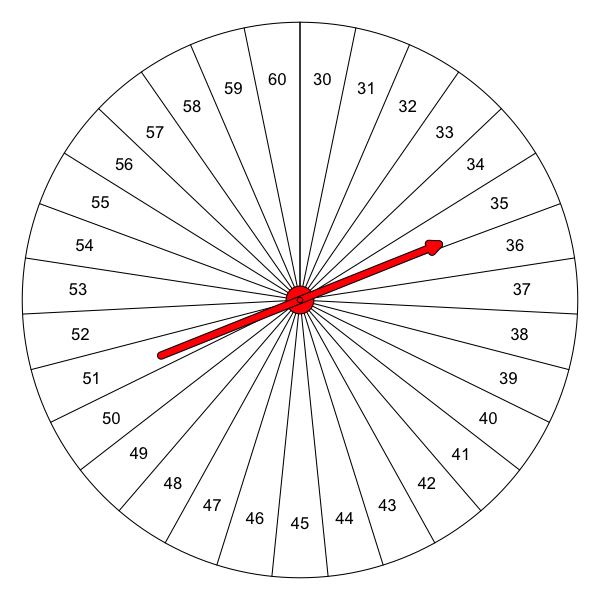

    The spinner was spun a few times, producing the values below.

    | x |
    | --- |
    | 31 |
    | 55 |
    | 46 |
    | 30 |
    | 57 |
    | 33 |
    | 50 |
    | 50 |
    | 51 |
    | 54 |
    | 53 |

    Please help describe the values by finding a few statistics.

### The sample size, $n$

    The sample size is simply a count of how many values are in the sample.
    - $n=$

### The sample total, $\sum x$

    The sample total is found by adding up all the values. Informally, we write it as $\sum x$. More formally, we write it as $\sum\limits_{i=1}^n x_i$. Notice, both methods refer to the [summation operator](https://en.wikipedia.org/wiki/Summation#Capital-sigma_notation).
    - $\sum x =$

### The sample mean, $\bar{x}$

    The [sample mean](https://en.wikipedia.org/wiki/Arithmetic_mean), or in common parlance “the sample average”, is found by dividing the sample total by the sample size. The symbol $\bar{x}$ is pronounced “x bar”. Please round to the nearest tenth.
    $$\bar{x} = \frac{\sum x}{n}$$
    - $\bar{x}=$

### The sample median

    The [median](https://en.wikipedia.org/wiki/Median) represents a boundary between the lower half of the values and the upper half of the values. This should be review. Remember, it helps to sort the data. We could write a formula using a [sort function](https://en.wikipedia.org/wiki/Sorting_algorithm) and [floor and ceiling functions](https://en.wikipedia.org/wiki/Floor_and_ceiling_functions):

    $$\mathrm{median}(x) ~=~ \frac{\mathrm{sort}(x)_{\lceil n/2\rceil}+\mathrm{sort}(x)_{\lfloor n/2+1\rfloor}}{2}$$

    But, you’ll probably just want to sort the values. Then, if the sample size is odd, find the middle value. If the sample size is even, find the mean of the two middle values.
    - $\mathrm{median}(x) =$

### A conditional count

    In data analysis, we often use [conditional counts](https://support.google.com/docs/answer/3093480?hl=en). In this case, I want you to count how many values are greater than 34. I am using the # symbol to represent a count, and in the parentheses I am denoting a condition (with an inequality).
    - $\#(x > 34) =$

### A sample proportion

    What proportion of the values are at most 41? A proportion is a conditional count divided by the sample size. Please round to the nearest hundredth.
    - $\mathrm{proportion(x\le 41)}= \frac{\#(x\le 41)}{n} =$

#### Solution

#### Question

25. A spinner was made to model a [discrete-uniform distribution](https://en.wikipedia.org/wiki/Discrete_uniform_distribution).

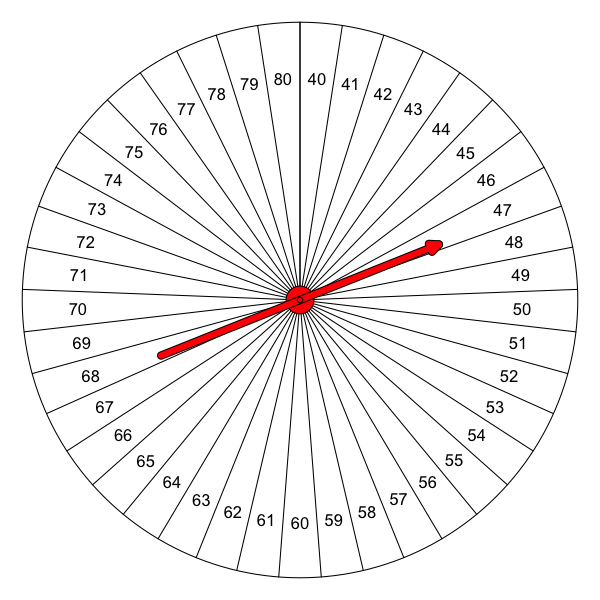

    The spinner was spun a few times, producing the values below.

    | x |
    | --- |
    | 46 |
    | 66 |
    | 48 |
    | 59 |
    | 73 |
    | 76 |
    | 68 |
    | 50 |
    | 41 |
    | 42 |
    | 77 |
    | 80 |

    Please help describe the values by finding a few statistics.

### The sample size, $n$

    The sample size is simply a count of how many values are in the sample.
    - $n=$

### The sample total, $\sum x$

    The sample total is found by adding up all the values. Informally, we write it as $\sum x$. More formally, we write it as $\sum\limits_{i=1}^n x_i$. Notice, both methods refer to the [summation operator](https://en.wikipedia.org/wiki/Summation#Capital-sigma_notation).
    - $\sum x =$

### The sample mean, $\bar{x}$

    The [sample mean](https://en.wikipedia.org/wiki/Arithmetic_mean), or in common parlance “the sample average”, is found by dividing the sample total by the sample size. The symbol $\bar{x}$ is pronounced “x bar”. Please round to the nearest tenth.
    $$\bar{x} = \frac{\sum x}{n}$$
    - $\bar{x}=$

### The sample median

    The [median](https://en.wikipedia.org/wiki/Median) represents a boundary between the lower half of the values and the upper half of the values. This should be review. Remember, it helps to sort the data. We could write a formula using a [sort function](https://en.wikipedia.org/wiki/Sorting_algorithm) and [floor and ceiling functions](https://en.wikipedia.org/wiki/Floor_and_ceiling_functions):

    $$\mathrm{median}(x) ~=~ \frac{\mathrm{sort}(x)_{\lceil n/2\rceil}+\mathrm{sort}(x)_{\lfloor n/2+1\rfloor}}{2}$$

    But, you’ll probably just want to sort the values. Then, if the sample size is odd, find the middle value. If the sample size is even, find the mean of the two middle values.
    - $\mathrm{median}(x) =$

### A conditional count

    In data analysis, we often use [conditional counts](https://support.google.com/docs/answer/3093480?hl=en). In this case, I want you to count how many values are greater than 55. I am using the # symbol to represent a count, and in the parentheses I am denoting a condition (with an inequality).
    - $\#(x > 55) =$

### A sample proportion

    What proportion of the values are less than 68? A proportion is a conditional count divided by the sample size. Please round to the nearest hundredth.
    - $\mathrm{proportion(x< 68)}= \frac{\#(x< 68)}{n} =$

#### Solution

#### Question

26. A spinner was made to model a [discrete-uniform distribution](https://en.wikipedia.org/wiki/Discrete_uniform_distribution).

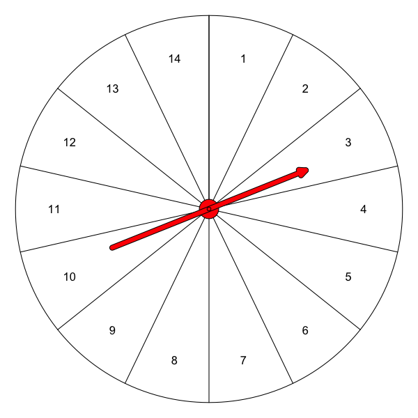

    The spinner was spun many times, producing the values below.

    | x |  |  |  |  |
    | --- | --- | --- | --- | --- |
    | 1 | 12 | 12 | 8 | 2 |
    | 10 | 11 | 2 | 10 | 1 |
    | 8 | 6 | 14 | 7 | 3 |
    | 5 | 3 | 1 | 1 | 3 |
    | 8 | 4 | 11 | 5 | 5 |
    | 5 | 9 | 3 | 1 | 12 |
    | 6 | 11 | 14 | 7 | 14 |
    | 14 | 12 | 12 | 6 | 3 |
    | 14 | 14 | 12 | 9 | 9 |
    | 1 | 8 | 8 | 5 | 9 |
    | 6 | 13 | 8 | 10 | 12 |
    | 5 | 5 | 11 | 11 | 3 |
    | 10 | 7 | 9 | 7 | 4 |

    Please help describe the values by finding a few statistics.

### The sample size, $n$

    The sample size is simply a count of how many values are in the sample.
    - $n=$

### The sample total, $\sum x$

    The sample total is found by adding up all the values. Informally, we write it as $\sum x$. More formally, we write it as $\sum\limits_{i=1}^n x_i$. Notice, both methods refer to the [summation operator](https://en.wikipedia.org/wiki/Summation#Capital-sigma_notation).
    - $\sum x =$

### The sample mean, $\bar{x}$

    The [sample mean](https://en.wikipedia.org/wiki/Arithmetic_mean), or in common parlance “the sample average”, is found by dividing the sample total by the sample size. The symbol $\bar{x}$ is pronounced “x bar”. Please round to the nearest tenth.
    $$\bar{x} = \frac{\sum x}{n}$$
    - $\bar{x}=$

### The sample median

    The [median](https://en.wikipedia.org/wiki/Median) represents a boundary between the lower half of the values and the upper half of the values. This should be review. Remember, it helps to sort the data. We could write a formula using a [sort function](https://en.wikipedia.org/wiki/Sorting_algorithm) and [floor and ceiling functions](https://en.wikipedia.org/wiki/Floor_and_ceiling_functions):

    $$\mathrm{median}(x) ~=~ \frac{\mathrm{sort}(x)_{\lceil n/2\rceil}+\mathrm{sort}(x)_{\lfloor n/2+1\rfloor}}{2}$$

    But, you’ll probably just want to sort the values. Then, if the sample size is odd, find the middle value. If the sample size is even, find the mean of the two middle values.
    - $\mathrm{median}(x) =$

### A conditional count

    In data analysis, we often use [conditional counts](https://support.google.com/docs/answer/3093480?hl=en). In this case, I want you to count how many values are greater than 7. I am using the # symbol to represent a count, and in the parentheses I am denoting a condition (with an inequality).
    - $\#(x > 7) =$

### A sample proportion

    What proportion of the values are less than 6? A proportion is a conditional count divided by the sample size. Please round to the nearest hundredth.
    - $\mathrm{proportion(x< 6)}= \frac{\#(x< 6)}{n} =$

#### Solution

#### Question

27. A spinner was made to model a [discrete-uniform distribution](https://en.wikipedia.org/wiki/Discrete_uniform_distribution).

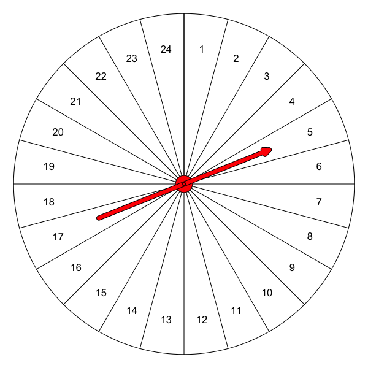

    The spinner was spun many times, producing the values below.

    | x |  |  |  |  |
    | --- | --- | --- | --- | --- |
    | 7 | 2 | 23 | 20 | 5 |
    | 8 | 14 | 6 | 13 | 22 |
    | 15 | 16 | 22 | 10 | 23 |
    | 21 | 9 | 17 | 16 | 11 |
    | 19 | 1 | 2 | 21 | 6 |
    | 2 | 20 | 15 | 9 | 8 |
    | 1 | 15 | 20 | 10 | 24 |
    | 11 | 9 | 24 | 21 | 7 |
    | 1 | 23 | 10 | 16 | 4 |
    | 18 | 17 | 24 | 20 | 13 |
    | 18 | 23 | 14 | 10 | 20 |
    | 7 | 1 | 19 | 18 | 20 |
    | 22 | 1 | 19 | 15 | 18 |
    | 23 | 20 | 13 | 8 | 12 |
    | 11 | 19 | 10 | 17 | 3 |
    | 12 | 1 | 22 | 4 | 16 |
    | 2 | 7 | 20 | 18 | 10 |

    Please help describe the values by finding a few statistics.

### The sample size, $n$

    The sample size is simply a count of how many values are in the sample.
    - $n=$

### The sample total, $\sum x$

    The sample total is found by adding up all the values. Informally, we write it as $\sum x$. More formally, we write it as $\sum\limits_{i=1}^n x_i$. Notice, both methods refer to the [summation operator](https://en.wikipedia.org/wiki/Summation#Capital-sigma_notation).
    - $\sum x =$

### The sample mean, $\bar{x}$

    The [sample mean](https://en.wikipedia.org/wiki/Arithmetic_mean), or in common parlance “the sample average”, is found by dividing the sample total by the sample size. The symbol $\bar{x}$ is pronounced “x bar”. Please round to the nearest tenth.
    $$\bar{x} = \frac{\sum x}{n}$$
    - $\bar{x}=$

### The sample median

    The [median](https://en.wikipedia.org/wiki/Median) represents a boundary between the lower half of the values and the upper half of the values. This should be review. Remember, it helps to sort the data. We could write a formula using a [sort function](https://en.wikipedia.org/wiki/Sorting_algorithm) and [floor and ceiling functions](https://en.wikipedia.org/wiki/Floor_and_ceiling_functions):

    $$\mathrm{median}(x) ~=~ \frac{\mathrm{sort}(x)_{\lceil n/2\rceil}+\mathrm{sort}(x)_{\lfloor n/2+1\rfloor}}{2}$$

    But, you’ll probably just want to sort the values. Then, if the sample size is odd, find the middle value. If the sample size is even, find the mean of the two middle values.
    - $\mathrm{median}(x) =$

### A conditional count

    In data analysis, we often use [conditional counts](https://support.google.com/docs/answer/3093480?hl=en). In this case, I want you to count how many values are less than 11. I am using the # symbol to represent a count, and in the parentheses I am denoting a condition (with an inequality).
    - $\#(x < 11) =$

### A sample proportion

    What proportion of the values are at least 12? A proportion is a conditional count divided by the sample size. Please round to the nearest hundredth.
    - $\mathrm{proportion(x\ge 12)}= \frac{\#(x\ge 12)}{n} =$

#### Solution

#### Question

28. A spinner was made to model a [discrete-uniform distribution](https://en.wikipedia.org/wiki/Discrete_uniform_distribution).

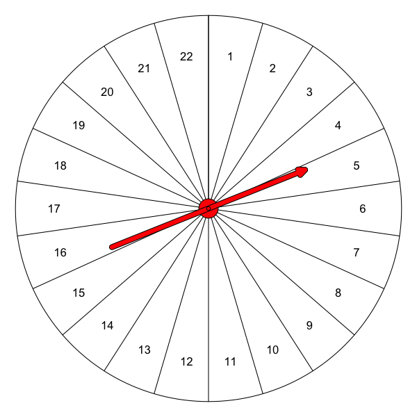

    The spinner was spun many times, producing the values below.

    | x |  |  |  |  |  |  |  |  |
    | --- | --- | --- | --- | --- | --- | --- | --- | --- |
    | 14 | 22 | 18 | 16 | 18 | 13 | 3 | 16 | 14 |
    | 19 | 22 | 16 | 1 | 13 | 14 | 10 | 4 | 15 |
    | 10 | 11 | 18 | 16 | 14 | 6 | 16 | 22 | 21 |
    | 7 | 15 | 19 | 17 | 15 | 13 | 22 | 15 | 21 |
    | 21 | 17 | 12 | 19 | 18 | 18 | 20 | 7 | 17 |
    | 21 | 21 | 5 | 8 | 21 | 15 | 5 | 11 | 20 |
    | 2 | 2 | 20 | 22 | 10 | 7 | 19 | 9 | 13 |
    | 22 | 10 | 11 | 3 | 14 | 22 | 5 | 11 | 1 |
    | 3 | 2 | 5 | 22 | 20 | 11 | 21 | 4 | 5 |
    | 10 | 17 | 1 | 5 | 19 | 22 | 2 | 3 | 12 |
    | 4 | 7 | 8 | 2 | 1 | 3 | 6 | 6 | 19 |
    | 2 | 19 | 1 | 16 | 16 | 18 | 22 | 6 | 13 |
    | 20 | 5 | 15 | 19 | 1 | 15 | 2 | 18 | 8 |

    Please help describe the values by finding a few statistics.

### The sample size, $n$

    The sample size is simply a count of how many values are in the sample.
    - $n=$

### The sample total, $\sum x$

    The sample total is found by adding up all the values. Informally, we write it as $\sum x$. More formally, we write it as $\sum\limits_{i=1}^n x_i$. Notice, both methods refer to the [summation operator](https://en.wikipedia.org/wiki/Summation#Capital-sigma_notation).
    - $\sum x =$

### The sample mean, $\bar{x}$

    The [sample mean](https://en.wikipedia.org/wiki/Arithmetic_mean), or in common parlance “the sample average”, is found by dividing the sample total by the sample size. The symbol $\bar{x}$ is pronounced “x bar”. Please round to the nearest tenth.
    $$\bar{x} = \frac{\sum x}{n}$$
    - $\bar{x}=$

### The sample median

    The [median](https://en.wikipedia.org/wiki/Median) represents a boundary between the lower half of the values and the upper half of the values. This should be review. Remember, it helps to sort the data. We could write a formula using a [sort function](https://en.wikipedia.org/wiki/Sorting_algorithm) and [floor and ceiling functions](https://en.wikipedia.org/wiki/Floor_and_ceiling_functions):

    $$\mathrm{median}(x) ~=~ \frac{\mathrm{sort}(x)_{\lceil n/2\rceil}+\mathrm{sort}(x)_{\lfloor n/2+1\rfloor}}{2}$$

    But, you’ll probably just want to sort the values. Then, if the sample size is odd, find the middle value. If the sample size is even, find the mean of the two middle values.
    - $\mathrm{median}(x) =$

### A conditional count

    In data analysis, we often use [conditional counts](https://support.google.com/docs/answer/3093480?hl=en). In this case, I want you to count how many values are at least 15. I am using the # symbol to represent a count, and in the parentheses I am denoting a condition (with an inequality).
    - $\#(x \ge 15) =$

### A sample proportion

    What proportion of the values are at most 18? A proportion is a conditional count divided by the sample size. Please round to the nearest hundredth.
    - $\mathrm{proportion(x\le 18)}= \frac{\#(x\le 18)}{n} =$

#### Solution

#### Question

29. A spinner was made to model a [discrete-uniform distribution](https://en.wikipedia.org/wiki/Discrete_uniform_distribution).

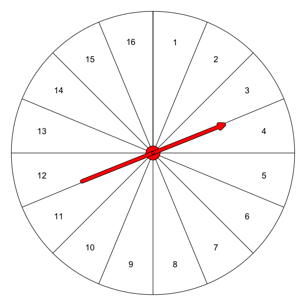

    The spinner was spun many times, producing the values below.

    | x |  |  |  |  |
    | --- | --- | --- | --- | --- |
    | 13 | 11 | 15 | 15 | 8 |
    | 2 | 16 | 11 | 11 | 10 |
    | 1 | 4 | 8 | 14 | 6 |
    | 13 | 4 | 10 | 4 | 16 |
    | 6 | 3 | 7 | 6 | 4 |
    | 2 | 14 | 2 | 6 | 3 |
    | 9 | 15 | 7 | 1 | 7 |
    | 15 | 11 | 5 | 11 | 8 |
    | 1 | 6 | 7 | 7 | 8 |
    | 2 | 8 | 12 | 16 | 16 |
    | 7 | 9 | 7 | 4 | 1 |
    | 13 | 4 | 12 | 11 | 5 |
    | 11 | 12 | 12 | 9 | 4 |

    Please help describe the values by finding a few statistics.

### The sample size, $n$

    The sample size is simply a count of how many values are in the sample.
    - $n=$

### The sample total, $\sum x$

    The sample total is found by adding up all the values. Informally, we write it as $\sum x$. More formally, we write it as $\sum\limits_{i=1}^n x_i$. Notice, both methods refer to the [summation operator](https://en.wikipedia.org/wiki/Summation#Capital-sigma_notation).
    - $\sum x =$

### The sample mean, $\bar{x}$

    The [sample mean](https://en.wikipedia.org/wiki/Arithmetic_mean), or in common parlance “the sample average”, is found by dividing the sample total by the sample size. The symbol $\bar{x}$ is pronounced “x bar”. Please round to the nearest tenth.
    $$\bar{x} = \frac{\sum x}{n}$$
    - $\bar{x}=$

### The sample median

    The [median](https://en.wikipedia.org/wiki/Median) represents a boundary between the lower half of the values and the upper half of the values. This should be review. Remember, it helps to sort the data. We could write a formula using a [sort function](https://en.wikipedia.org/wiki/Sorting_algorithm) and [floor and ceiling functions](https://en.wikipedia.org/wiki/Floor_and_ceiling_functions):

    $$\mathrm{median}(x) ~=~ \frac{\mathrm{sort}(x)_{\lceil n/2\rceil}+\mathrm{sort}(x)_{\lfloor n/2+1\rfloor}}{2}$$

    But, you’ll probably just want to sort the values. Then, if the sample size is odd, find the middle value. If the sample size is even, find the mean of the two middle values.
    - $\mathrm{median}(x) =$

### A conditional count

    In data analysis, we often use [conditional counts](https://support.google.com/docs/answer/3093480?hl=en). In this case, I want you to count how many values are at most 7. I am using the # symbol to represent a count, and in the parentheses I am denoting a condition (with an inequality).
    - $\#(x \le 7) =$

### A sample proportion

    What proportion of the values are at least 12? A proportion is a conditional count divided by the sample size. Please round to the nearest hundredth.
    - $\mathrm{proportion(x\ge 12)}= \frac{\#(x\ge 12)}{n} =$

#### Solution

#### Question

30. A spinner was made to model a [discrete-uniform distribution](https://en.wikipedia.org/wiki/Discrete_uniform_distribution).

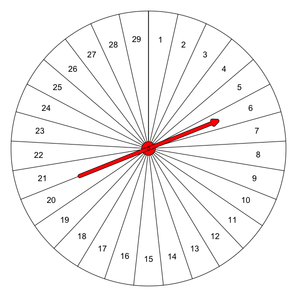

    The spinner was spun many times, producing the values below.

    | x |  |  |  |  |  |  |
    | --- | --- | --- | --- | --- | --- | --- |
    | 22 | 10 | 4 | 13 | 13 | 26 | 27 |
    | 28 | 2 | 22 | 7 | 29 | 25 | 13 |
    | 10 | 27 | 3 | 15 | 19 | 3 | 9 |
    | 14 | 7 | 4 | 23 | 19 | 22 | 23 |
    | 14 | 26 | 9 | 24 | 5 | 20 | 14 |
    | 5 | 29 | 15 | 10 | 11 | 26 | 19 |
    | 17 | 23 | 14 | 7 | 9 | 17 | 14 |
    | 16 | 12 | 26 | 11 | 28 | 2 | 7 |
    | 11 | 1 | 5 | 4 | 21 | 2 | 20 |
    | 22 | 8 | 24 | 1 | 19 | 4 | 15 |
    | 23 | 28 | 15 | 7 | 16 | 15 | 26 |
    | 14 | 19 | 7 | 14 | 17 | 25 | 3 |
    | 4 | 11 | 9 | 24 | 6 | 1 | 25 |
    | 3 | 16 | 16 | 19 | 12 | 23 | 19 |
    | 26 | 19 | 7 | 26 | 16 | 5 | 3 |
    | 29 | 14 | 27 | 6 | 23 | 4 | 20 |
    | 21 | 29 | 4 | 17 | 29 | 8 | 23 |
    | 5 | 13 | 28 | 6 | 8 | 10 | 16 |
    | 26 | 3 | 20 | 28 | 22 | 26 | 28 |

    Please help describe the values by finding a few statistics.

### The sample size, $n$

    The sample size is simply a count of how many values are in the sample.
    - $n=$

### The sample total, $\sum x$

    The sample total is found by adding up all the values. Informally, we write it as $\sum x$. More formally, we write it as $\sum\limits_{i=1}^n x_i$. Notice, both methods refer to the [summation operator](https://en.wikipedia.org/wiki/Summation#Capital-sigma_notation).
    - $\sum x =$

### The sample mean, $\bar{x}$

    The [sample mean](https://en.wikipedia.org/wiki/Arithmetic_mean), or in common parlance “the sample average”, is found by dividing the sample total by the sample size. The symbol $\bar{x}$ is pronounced “x bar”. Please round to the nearest tenth.
    $$\bar{x} = \frac{\sum x}{n}$$
    - $\bar{x}=$

### The sample median

    The [median](https://en.wikipedia.org/wiki/Median) represents a boundary between the lower half of the values and the upper half of the values. This should be review. Remember, it helps to sort the data. We could write a formula using a [sort function](https://en.wikipedia.org/wiki/Sorting_algorithm) and [floor and ceiling functions](https://en.wikipedia.org/wiki/Floor_and_ceiling_functions):

    $$\mathrm{median}(x) ~=~ \frac{\mathrm{sort}(x)_{\lceil n/2\rceil}+\mathrm{sort}(x)_{\lfloor n/2+1\rfloor}}{2}$$

    But, you’ll probably just want to sort the values. Then, if the sample size is odd, find the middle value. If the sample size is even, find the mean of the two middle values.
    - $\mathrm{median}(x) =$

### A conditional count

    In data analysis, we often use [conditional counts](https://support.google.com/docs/answer/3093480?hl=en). In this case, I want you to count how many values are at most 20. I am using the # symbol to represent a count, and in the parentheses I am denoting a condition (with an inequality).
    - $\#(x \le 20) =$

### A sample proportion

    What proportion of the values are greater than 7? A proportion is a conditional count divided by the sample size. Please round to the nearest hundredth.
    - $\mathrm{proportion(x> 7)}= \frac{\#(x> 7)}{n} =$

#### Solution